# STAT/MATH 495: Problem Set 02

Anthony Rentsch

2017-09-19

# Exploratory Data Analysis

Visualizing the distribution of sale price using a histogram, we can see the data has a strong right skew. We might consider a transformation to make sale price more normally distributed. However, for the sake of model interpretability, we chose to proceed with sale price untransformed.

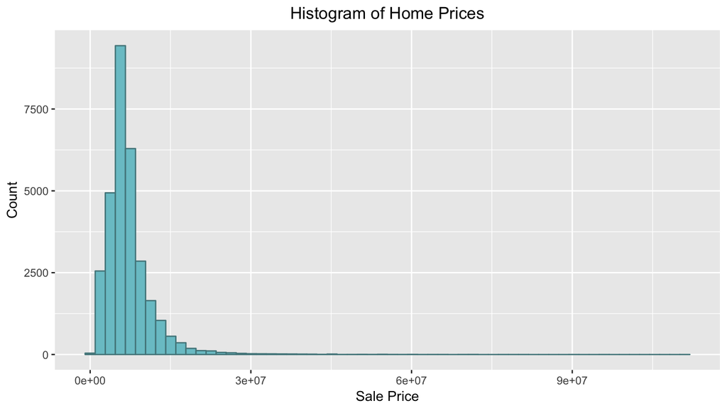

```r
ggplot(data = train) + geom_histogram(aes(x = price_doc), fill = "cadetblue3", bins = 60, color = "cadetblue4")+ ggtitle("Histogram of Home Prices") +
  xlab("Sale Price") +
  ylab("Count") +
  theme(plot.title = element_text(hjust = 0.5))
```

Visualize correlation between all structure describing variables with high availability in the data set, excluding observations with NA values.

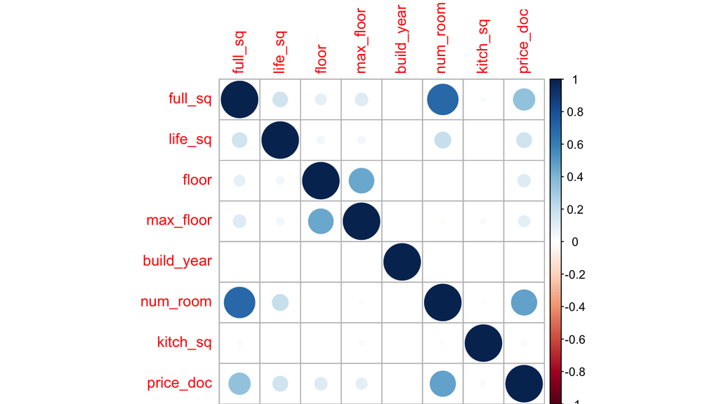

```r
new <- train[,c(3,4,5,6,8,9,10,292)]
M <- cor(new, use="pairwise.complete.obs")
corrplot(M, method = "circle")
```

The num_rooms variable looks like it has strongest linear correlation with price_doc so we chose num_rooms to create our splines model.

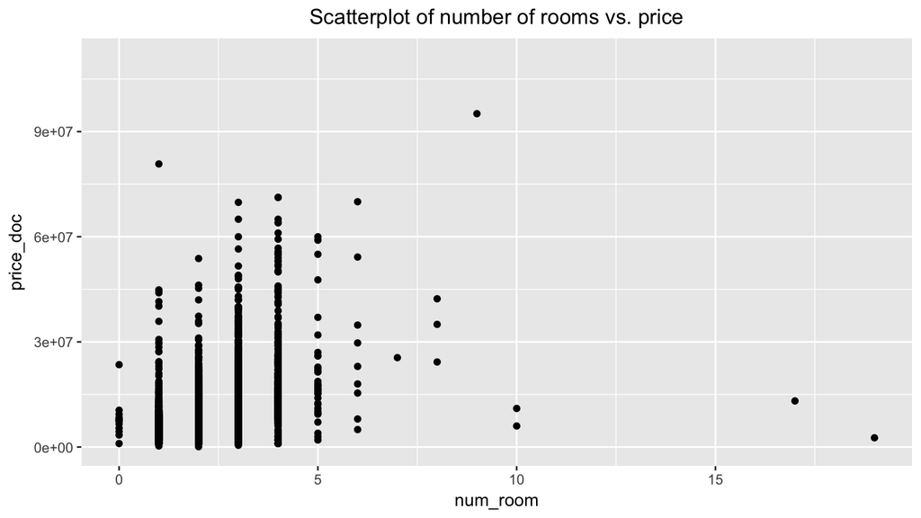

```r
ggplot(data = train) + geom_point(aes(x = num_room, y = price_doc)) +
  labs(title = "Scatterplot of number of rooms vs. price") +
  theme(plot.title = element_text(hjust = 0.5))
```

# Model Fit

Remove properties for which the number of rooms is not included.

```r
new.train <- train[-which(is.na(train$num_room)),]
```

Fit spline models for four different degress of freedom.

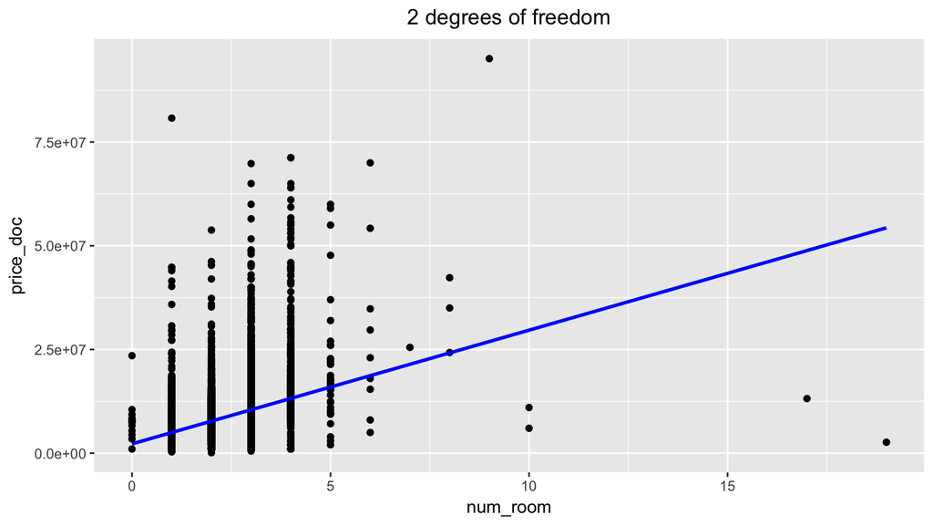

```r
two <- smooth.spline(new.train$num_room, new.train$price_doc, df=2) %>%
  broom::augment() %>%
  ggplot(aes(x = new.train$num_room)) +
  geom_point(aes(y = new.train$price_doc)) +
  geom_line(aes(y=.fitted), col="blue", size=1) +
  labs(title = "2 degrees of freedom", x = "num_room", y = "price_doc") +
  theme(plot.title = element_text(hjust = 0.5))

seven <- smooth.spline(new.train$num_room, new.train$price_doc, df=7) %>%
  broom::augment() %>%
  ggplot(aes(x = new.train$num_room)) +
  geom_point(aes(y = new.train$price_doc)) +
  geom_line(aes(y=.fitted), col="blue", size=1) +
  labs(title = "7 degrees of freedom", x = "num_room", y = "price_doc") +
  theme(plot.title = element_text(hjust = 0.5))

 ten <- smooth.spline(new.train$num_room, new.train$price_doc, df=10) %>%
  broom::augment() %>%
  ggplot(aes(x = new.train$num_room)) +
  geom_point(aes(y = new.train$price_doc)) +
  geom_line(aes(y=.fitted), col="blue", size=1) +
  labs(title = "10 degrees of freedom", x = "num_room", y = "price_doc") +
   theme(plot.title = element_text(hjust = 0.5))

thirteen <- smooth.spline(new.train$num_room, new.train$price_doc, df=13) %>%
  broom::augment() %>%
  ggplot(aes(x = new.train$num_room)) +
  geom_point(aes(y = new.train$price_doc)) +
  geom_line(aes(y=.fitted), col="blue", size=1) +
  labs(title = "13 degrees of freedom", x = "num_room", y = "price_doc") +
  theme(plot.title = element_text(hjust = 0.5))

two
```

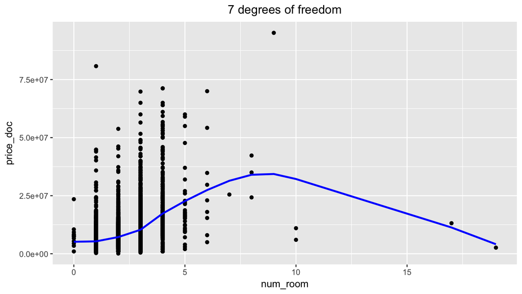

```r
seven
```

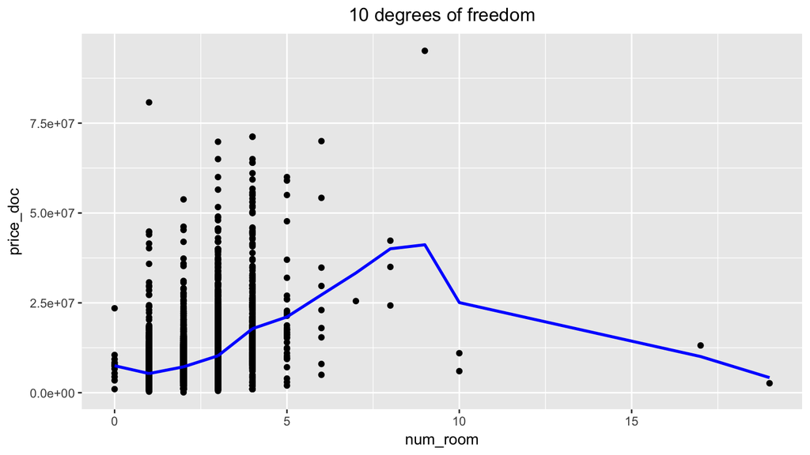

```r
ten
```

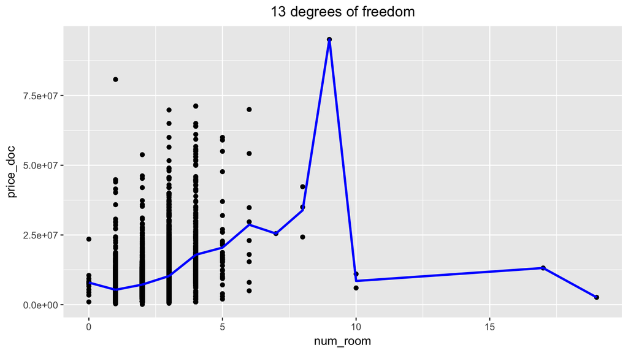

```r
thirteen
```

# Review and Create Submission File

Will use df = 7 to create spline model, as it appears to give best fit based on our plots.

```r
spline.model <- smooth.spline(new.train$num_room, new.train$price_doc, df = 7)
```

Predict the price_doc for the test set using spline.model.

```r
new_data = test$num_room
pred <- predict(spline.model, new_data)
pred <- as.data.frame(pred)
```

Plot original data, spline model, and predictions.

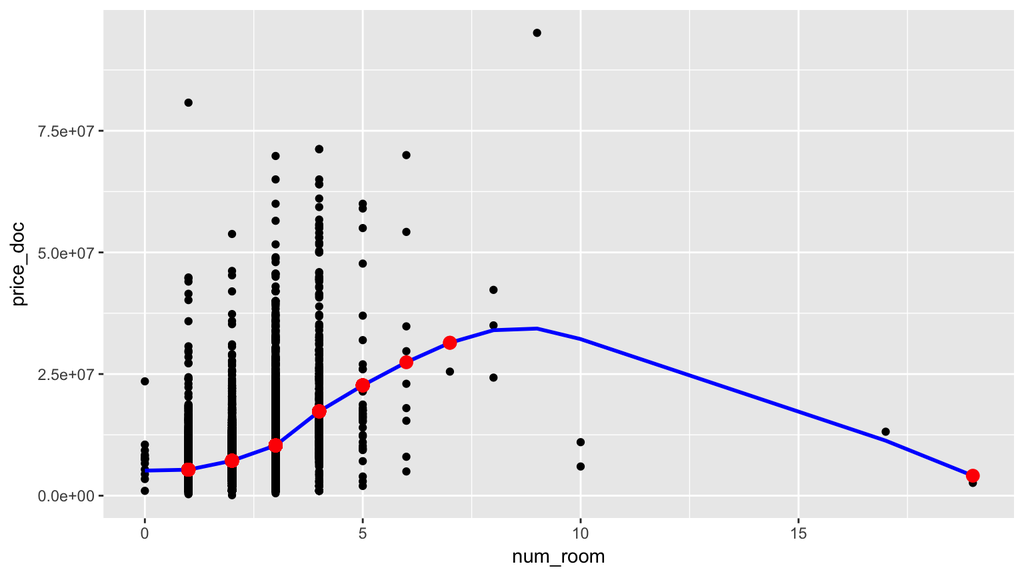

```r
spline.model %>% broom::augment() %>% ggplot() +
  geom_point(aes(x = new.train$num_room, y = new.train$price_doc)) +
  geom_line(aes(x = new.train$num_room, y=.fitted), col="blue", size=1) +
  geom_point(data = pred, aes(x = pred$x, y = pred$y), col = "red", size = 3) +
  labs(x = "num_room", y = "price_doc")
```

Create a clean list with id and predicted price_doc and write this list to a .csv file.

```r
pred <- cbind(id = test$id, pred)
pred <- pred[,-2]
colnames(pred) <- c("id","price_doc")

write.csv(pred, file = "submission.csv", row.names = F)
```